# Exploratory Data Analisys

## Exploring Diamonds dataset from ggplot2 package

Diamonds is a dataset which contains prices and other attribues of almost 54,000 diamonds. In fact, they are 53,940 observations and 10 variables, shown below:

| Variable | Description |
| --- | --- |
| price | price in America dollars (US$326–US$18,823) |
| carat | diamond weight (0.2–5.01) |
| cut | cut quality (Fair, Good, Very Good, Premium, Ideal) |
| color | diamond color, from J (worst) to D (best) |
| clarity | measure of how clear the diamond is (I1 (worst), SI2, SI1, VS2, VS1, VVS2, VVS1, IF (best)) |
| x | length in mm (0–10.74) |
| y | width in mm (0–58.9) |
| z | depth in mm (0–31.8) |
| depth | total depth in percent = z / mean(x, y) = 2 * z / (x + y) (43–79) |
| table | width of the diamond top related to the wider point (43–95) |

### Read dataset

Below we import the diamonds dataset inclued in ggplot2 package.

```r
library(ggplot2)
library(tidyverse)
dsDiamonds <- diamonds
```

### Dataset structure

The Diamond dataset has 10 attributes with the following structure:

```r
str(dsDiamonds,strict.width = "wrap",give.attr=FALSE)
```

```
## tibble [53,940 x 10] (S3: tbl_df/tbl/data.frame)
## $ carat : num [1:53940] 0.23 0.21 0.23 0.29 0.31 0.24 0.24 0.26 0.22 0.23 ...
## $ cut : Ord.factor w/ 5 levels "Fair"<"Good"<..: 5 4 2 4 2 3 3 3 1 3 ...
## $ color : Ord.factor w/ 7 levels "D"<"E"<"F"<"G"<..: 2 2 2 6 7 7 6 5 2 5 ...
## $ clarity: Ord.factor w/ 8 levels "I1"<"SI2"<"SI1"<..: 2 3 5 4 2 6 7 3 4 5 ...
## $ depth : num [1:53940] 61.5 59.8 56.9 62.4 63.3 62.8 62.3 61.9 65.1 59.4 ...
## $ table : num [1:53940] 55 61 65 58 58 57 57 55 61 61 ...
## $ price : int [1:53940] 326 326 327 334 335 336 336 337 337 338 ...
## $ x : num [1:53940] 3.95 3.89 4.05 4.2 4.34 3.94 3.95 4.07 3.87 4 ...
## $ y : num [1:53940] 3.98 3.84 4.07 4.23 4.35 3.96 3.98 4.11 3.78 4.05 ...
## $ z : num [1:53940] 2.43 2.31 2.31 2.63 2.75 2.48 2.47 2.53 2.49 2.39 ...
```

As we can observe, the output of str() function matches the dataset description. There are 3 qualitative ordinal attributes, i.e. they are categorical variables with ordinal classification (in this case, from worst to best):

- cut
- color
- clarity

All other variables are numerical continuous.

### Checking begin and end of the dataset

```r
head(dsDiamonds)
```

```
## # A tibble: 6 x 10
##   carat cut       color clarity depth table price     x     y     z
##   <dbl> <ord>     <ord> <ord>   <dbl> <dbl> <int> <dbl> <dbl> <dbl>
## 1 0.23  Ideal     E     SI2      61.5    55   326  3.95  3.98  2.43
## 2 0.21  Premium   E     SI1      59.8    61   326  3.89  3.84  2.31
## 3 0.23  Good      E     VS1      56.9    65   327  4.05  4.07  2.31
## 4 0.290 Premium   I     VS2      62.4    58   334  4.2   4.23  2.63
## 5 0.31  Good      J     SI2      63.3    58   335  4.34  4.35  2.75
## 6 0.24  Very Good J     VVS2     62.8    57   336  3.94  3.96  2.48
```

```r
tail(dsDiamonds)
```

```
## # A tibble: 6 x 10
##   carat cut       color clarity depth table price     x     y     z
##   <dbl> <ord>     <ord> <ord>   <dbl> <dbl> <int> <dbl> <dbl> <dbl>
## 1  0.72 Premium   D     SI1      62.7    59  2757  5.69  5.73  3.58
## 2  0.72 Ideal     D     SI1      60.8    57  2757  5.75  5.76  3.5
## 3  0.72 Good      D     SI1      63.1    55  2757  5.69  5.75  3.61
## 4  0.7  Very Good D     SI1      62.8    60  2757  5.66  5.68  3.56
## 5  0.86 Premium   H     SI2      61      58  2757  6.15  6.12  3.74
## 6  0.75 Ideal     D     SI2      62.2    55  2757  5.83  5.87  3.64
```

Based on the output of head and tail functions the dataset seems to be according to the description.

### Statistical summary

Statistical summary with summary() fuction:

```r
summary(dsDiamonds)
```

```
##      carat               cut        color        clarity          depth
##  Min.   :0.2000   Fair     : 1610   D: 6775   SI1    :13065   Min.   :43.00
##  1st Qu.:0.4000   Good     : 4906   E: 9797   VS2    :12258   1st Qu.:61.00
##  Median :0.7000   Very Good:12082   F: 9542   SI2    : 9194   Median :61.80
##  Mean   :0.7979   Premium  :13791   G:11292   VS1    : 8171   Mean   :61.75
##  3rd Qu.:1.0400   Ideal    :21551   H: 8304   VVS2   : 5066   3rd Qu.:62.50
##  Max.   :5.0100                     I: 5422   VVS1   : 3655   Max.   :79.00
##                                     J: 2808   (Other): 2531
##      table           price             x                y
##  Min.   :43.00   Min.   :  326   Min.   : 0.000   Min.   : 0.000
##  1st Qu.:56.00   1st Qu.:  950   1st Qu.: 4.710   1st Qu.: 4.720
##  Median :57.00   Median : 2401   Median : 5.700   Median : 5.710
##  Mean   :57.46   Mean   : 3933   Mean   : 5.731   Mean   : 5.735
##  3rd Qu.:59.00   3rd Qu.: 5324   3rd Qu.: 6.540   3rd Qu.: 6.540
##  Max.   :95.00   Max.   :18823   Max.   :10.740   Max.   :58.900
##
##        z
##  Min.   : 0.000
##  1st Qu.: 2.910
##  Median : 3.530
##  Mean   : 3.539
##  3rd Qu.: 4.040
##  Max.   :31.800
##
```

Inspecting the attributes with summary function output:

- price: matches the description with a minimum value of US$ 326 and maximum of US$ 18,823
- carat: matches the description varying from 0.2 to 5.01
- cut: matches the description varying from “Fair” to “Ideal” (no null values)
- color: matches the description, there are no null values
- clarity: seems to match the description; have to investigate “others”
- x: matches the description varying from 0 to 10.74
- y: matches the description varying from 0 to 58.9
- z: matches the description varying from 0 to 31.8
- depth: matches the description varying from 43 to 79
- table: matches the description varying from 43 to 95

The summary function gives us more insights in its output:

- the carat attribute has a median very low comparing to the maximum value. This may indicate possible outliers as we can observe that 3rd quartile presents a value not so far from the median, i.e. up to 75% of the observations have an “expected” carat value with respect to the median;
- we can observe the same behavior in the price attributes y and z (maximum values very above the median indicating possible outliers)

Checking what values are part of “others” in the clarity output:

```r
`%notin%` <- Negate(`%in%`)
subset(dsDiamonds, dsDiamonds$clarity %notin% c("SI1","VS2","SI2","VS1","VVS2","VVS1")) %>%
  summary()
```

```
##      carat               cut       color      clarity         depth
##  Min.   :0.2300   Fair     : 219   D:115   IF     :1790   Min.   :52.30
##  1st Qu.:0.3200   Good     : 167   E:260   I1     : 741   1st Qu.:61.00
##  Median :0.5000   Very Good: 352   F:528   SI2    :   0   Median :61.80
##  Mean   :0.7331   Premium  : 435   G:831   SI1    :   0   Mean   :61.87
##  3rd Qu.:1.0200   Ideal    :1358   H:461   VS2    :   0   3rd Qu.:62.30
##  Max.   :5.0100                    I:235   VS1    :   0   Max.   :78.20
##                                    J:101   (Other):   0
##      table           price               x                y
##  Min.   :52.00   Min.   :  345.0   Min.   : 3.860   Min.   : 3.880
##  1st Qu.:55.00   1st Qu.:  938.5   1st Qu.: 4.420   1st Qu.: 4.440
##  Median :57.00   Median : 1389.0   Median : 5.040   Median : 5.040
##  Mean   :57.03   Mean   : 3175.0   Mean   : 5.493   Mean   : 5.493
##  3rd Qu.:58.00   3rd Qu.: 3643.0   3rd Qu.: 6.480   3rd Qu.: 6.470
##  Max.   :67.00   Max.   :18806.0   Max.   :10.740   Max.   :10.540
##
##        z
##  Min.   :0.000
##  1st Qu.:2.730
##  Median :3.110
##  Mean   :3.397
##  3rd Qu.:4.000
##  Max.   :6.980
##
```

As we can see, the output “others” is related to the total of classifications “I1” and “IF” for clarity. We can also verify there are no null values for this attribute.

Checking the attributes x, y and z (lenght, width and depth), we encounter the following results:

- total observations with x = 0:

```r
sum(dsDiamonds$x == 0)
```

```
## [1] 8
```

- total observations with y = 0:

```r
sum(dsDiamonds$y == 0)
```

```
## [1] 7
```

- total observations with z = 0:

```r
sum(dsDiamonds$z == 0)
```

```
## [1] 20
```

```r
subset(dsDiamonds, dsDiamonds$z == 0)
```

```
## # A tibble: 20 x 10
##    carat cut       color clarity depth table price     x     y     z
##    <dbl> <ord>     <ord> <ord>   <dbl> <dbl> <int> <dbl> <dbl> <dbl>
##  1  1    Premium   G     SI2      59.1    59  3142  6.55  6.48     0
##  2  1.01 Premium   H     I1       58.1    59  3167  6.66  6.6      0
##  3  1.1  Premium   G     SI2      63      59  3696  6.5   6.47     0
##  4  1.01 Premium   F     SI2      59.2    58  3837  6.5   6.47     0
##  5  1.5  Good      G     I1       64      61  4731  7.15  7.04     0
##  6  1.07 Ideal     F     SI2      61.6    56  4954  0     6.62     0
##  7  1    Very Good H     VS2      63.3    53  5139  0     0        0
##  8  1.15 Ideal     G     VS2      59.2    56  5564  6.88  6.83     0
##  9  1.14 Fair      G     VS1      57.5    67  6381  0     0        0
## 10  2.18 Premium   H     SI2      59.4    61 12631  8.49  8.45     0
## 11  1.56 Ideal     G     VS2      62.2    54 12800  0     0        0
## 12  2.25 Premium   I     SI1      61.3    58 15397  8.52  8.42     0
## 13  1.2  Premium   D     VVS1     62.1    59 15686  0     0        0
## 14  2.2  Premium   H     SI1      61.2    59 17265  8.42  8.37     0
## 15  2.25 Premium   H     SI2      62.8    59 18034  0     0        0
## 16  2.02 Premium   H     VS2      62.7    53 18207  8.02  7.95     0
## 17  2.8  Good      G     SI2      63.8    58 18788  8.9   8.85     0
## 18  0.71 Good      F     SI2      64.1    60  2130  0     0        0
## 19  0.71 Good      F     SI2      64.1    60  2130  0     0        0
## 20  1.12 Premium   G     I1       60.4    59  2383  6.71  6.67     0
```

We can verify that despite the zero values for these measure attributes, the other attributes possess significant values in the same observation. Hence, there are some absence of values for these attributes that may or may not impact the model. We could simply eliminate these lines or use some algorithm (such as KNN) to populate these values.

### Exploring price attribute

Histogram of price attribute:

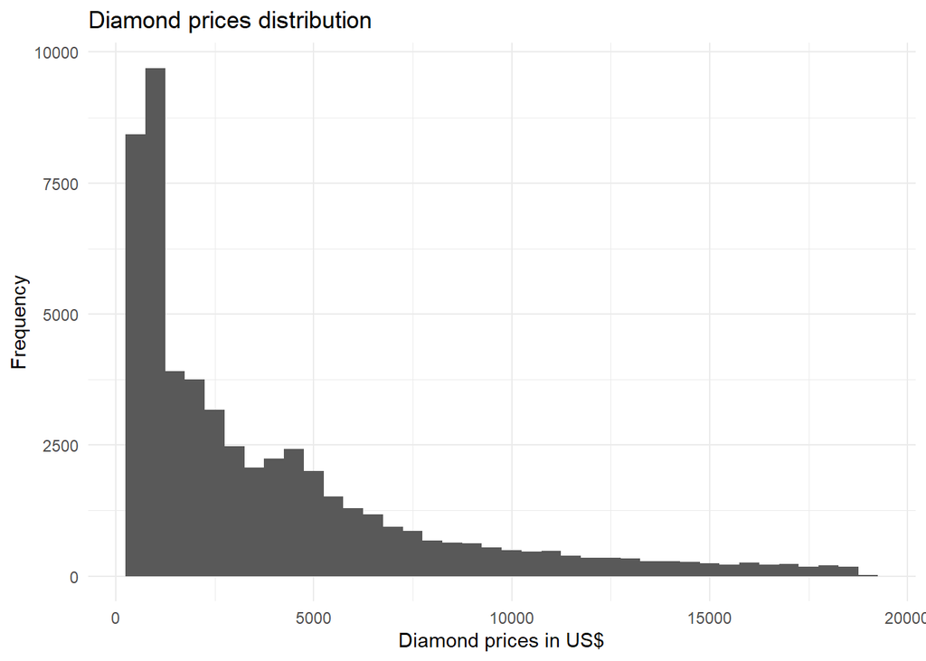

```r
ggplot(data=dsDiamonds) + geom_histogram(binwidth = 500, aes(x=price)) + ggtitle("Diamond prices distribution") + xlab("Diamond prices in US$") + ylab("Frequency") + theme_minimal()
```

According to the histogram we have a peak in a very low value (below US$ 1,000) and a long tail to the right, with quantities reducing considerably above this price range.

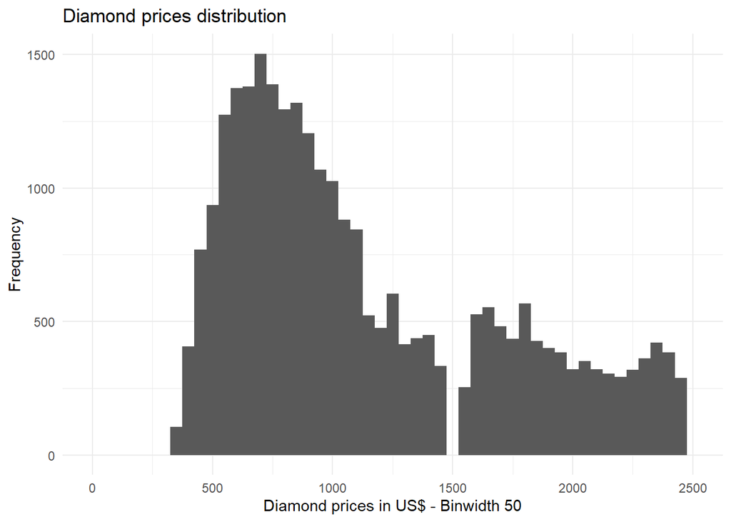

```r
ggplot(data=dsDiamonds) + geom_histogram(binwidth = 50, aes(x=price)) + ggtitle("Diamond prices distribution") + xlab("Diamond prices in US$ - Binwidth 50") + ylab("Frequency") + theme_minimal() + xlim(0,2500)
```

We can better verify the values close to the peak when limiting the x value until US$ 2,500 and reducing the “binwidth”. This way it is possible to visualize the distributions per price range.

### Other attributes distribution

Let us analyze the distribution of other attributes. First, the numerical attributes:

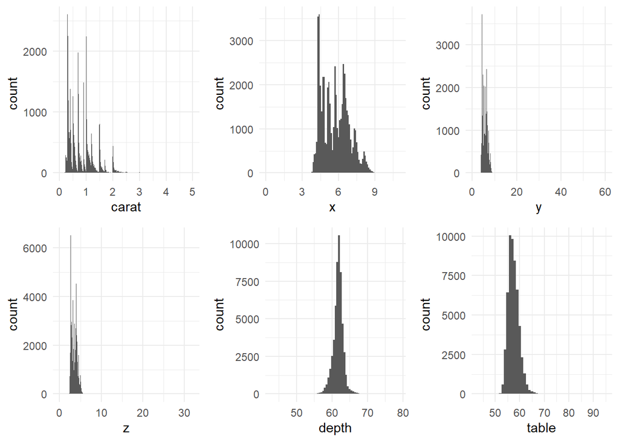

```r
library(ggpubr)
carat <- ggplot(data = dsDiamonds) + geom_histogram(aes(carat), binwidth = 0.01) + xlim(0,5) + labs_pubr() + theme_minimal()
x <- ggplot(data = dsDiamonds) + geom_histogram(aes(x), binwidth = 0.1) + xlim(0,11) + labs_pubr() + theme_minimal()
y <- ggplot(data = dsDiamonds) + geom_histogram(aes(y), binwidth = 0.1) + xlim(0,60) + labs_pubr() + theme_minimal()
z <- ggplot(data = dsDiamonds) + geom_histogram(aes(z), binwidth = 0.1) + xlim(0,32) + labs_pubr() + theme_minimal()
depth <- ggplot(data = dsDiamonds) + geom_histogram(aes(depth), binwidth = 0.5) + xlim(43,79) + labs_pubr() + theme_minimal()
table <- ggplot(data = dsDiamonds) + geom_histogram(aes(table), binwidth = 1) + xlim(43,95) + labs_pubr() + theme_minimal()
ggarrange(ncol = 3, nrow = 2, carat,x,y,z,depth,table)
```

Below we can see the distribution for the categorical attributes:

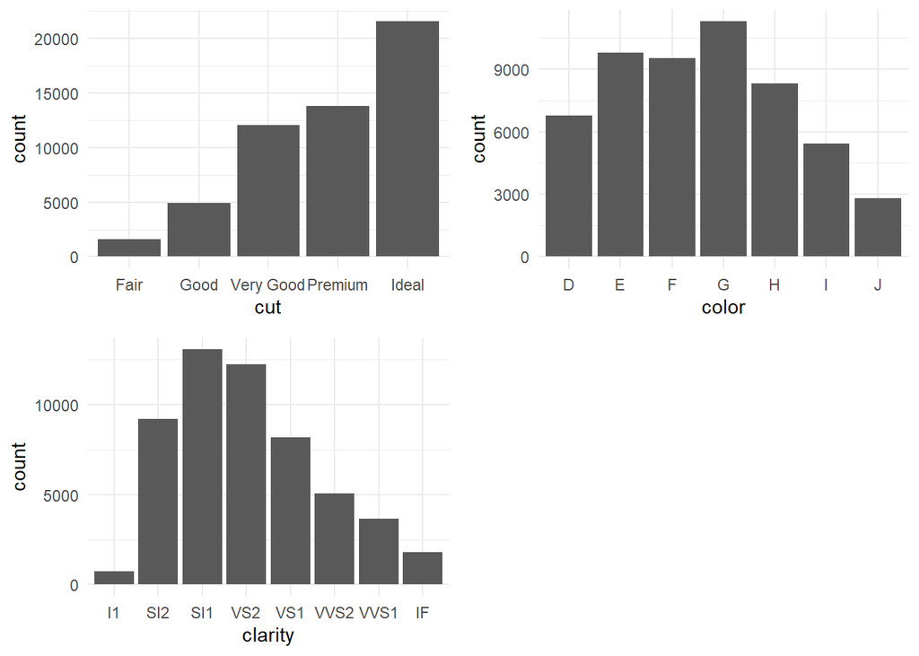

```r
cut <- ggplot(data = dsDiamonds) + geom_bar(aes(cut)) + labs_pubr() + theme_minimal()
color <- ggplot(data = dsDiamonds) + geom_bar(aes(color)) + labs_pubr() + theme_minimal()
clarity <- ggplot(data = dsDiamonds) + geom_bar(aes(clarity)) + labs_pubr() + theme_minimal()
ggarrange(ncol = 2, nrow = 2,cut,color,clarity)
```

### Outliers analysis

Let us explore the boxplots for numerical attributes:

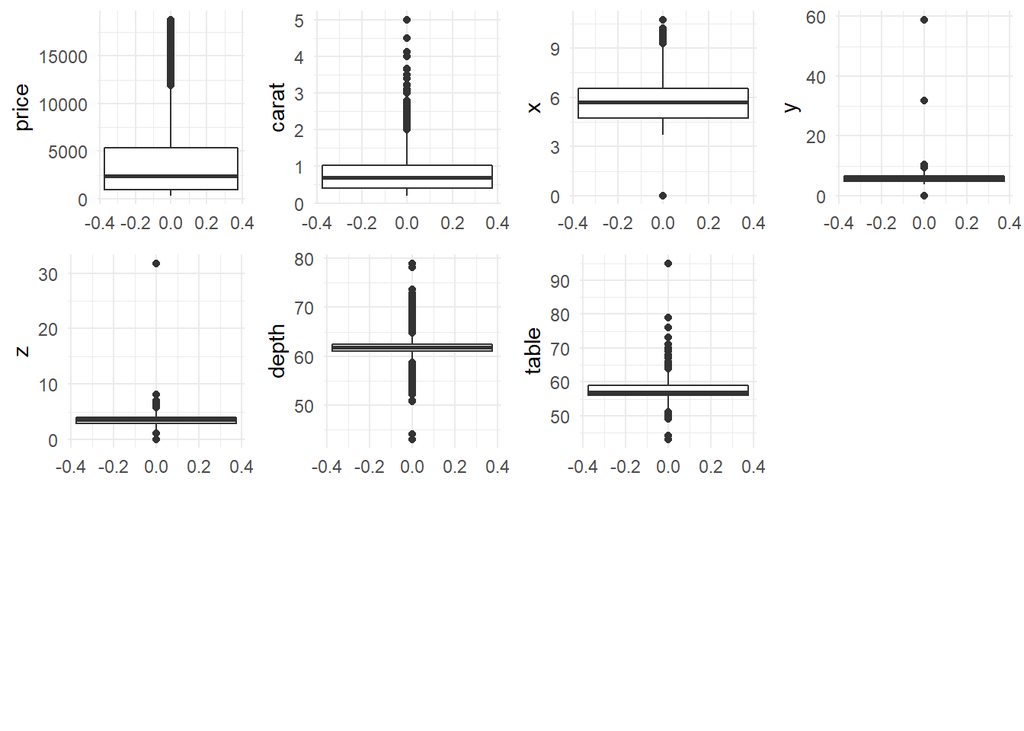

```r
price <- ggplot(data = dsDiamonds) + geom_boxplot(aes(y = price)) + labs_pubr() + theme_minimal()
carat <- ggplot(data = dsDiamonds) + geom_boxplot(aes(y = carat)) + labs_pubr() + theme_minimal()
x <- ggplot(data = dsDiamonds) + geom_boxplot(aes(y = x)) + labs_pubr() + theme_minimal()
y <- ggplot(data = dsDiamonds) + geom_boxplot(aes(y = y)) + labs_pubr() + theme_minimal()
z <- ggplot(data = dsDiamonds) + geom_boxplot(aes(y = z)) + labs_pubr() + theme_minimal()
depth <- ggplot(data = dsDiamonds) + geom_boxplot(aes(y = depth)) + labs_pubr() + theme_minimal()
table <- ggplot(data = dsDiamonds) + geom_boxplot(aes(y = table)) + labs_pubr() + theme_minimal()
ggarrange(ncol = 4, nrow = 3, price,carat,x,y,z,depth,table)
```

We can see some outliers in all attributes where some very high values stand out of the majority of the observation values for price and carat.

According to diamond specialists*, the diamond price depends on color and clarity graduations besides its cut and carat. Let us explore the price of the diamonds in respect to these attributes:

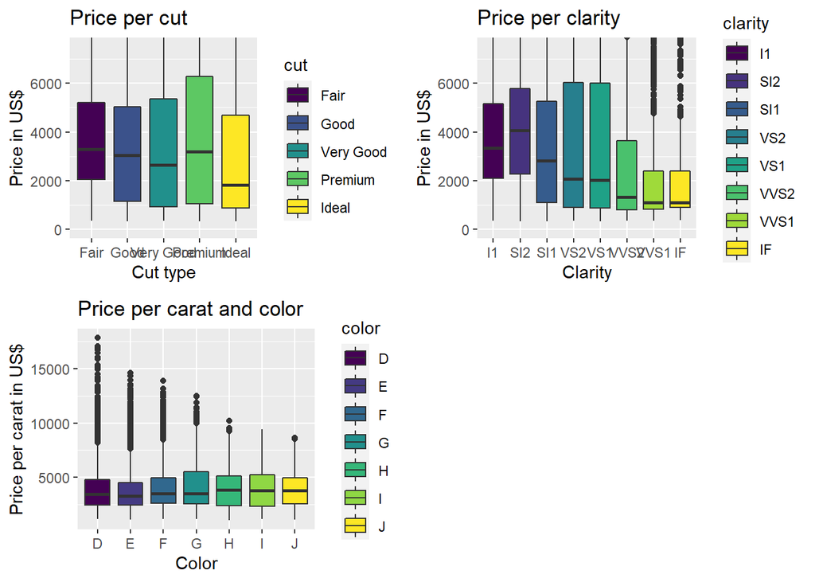

```r
price_cut <- ggplot(dsDiamonds, aes(factor(cut), price, fill=cut)) + geom_boxplot() + ggtitle("Price per cut") + xlab("Cut type") + ylab("Price in US$") + coord_cartesian(ylim=c(0,7500))
price_clarity <- ggplot(dsDiamonds, aes(factor(clarity), price, fill=clarity)) + geom_boxplot() + ggtitle("Price per clarity") + xlab("Clarity") + ylab("Price in US$") + coord_cartesian(ylim=c(0,7500))
price_carat_color <- ggplot(dsDiamonds, aes(factor(color), (price/carat), fill=color)) + geom_boxplot() + ggtitle("Price per carat and color") + xlab("Color") + ylab("Price per carat in US$")
ggarrange(ncol = 2, nrow = 2,price_cut,price_clarity,price_carat_color)
```

https://www.gemsociety.org/article/what-determines-diamond-cost

When analyzing these graphs, we can see some over-estimated prices mostly when considering clarity and carat/color.

Let us verify if we can have a correlation with carat:

```r
subset(dsDiamonds,dsDiamonds$carat > 1) %>%
  count()
```

```
## # A tibble: 1 x 1
##       n
##   <int>
## 1 17502
```

```r
subset(dsDiamonds,dsDiamonds$carat > 1 & dsDiamonds$price > 3500) %>%
  count()
```

```
## # A tibble: 1 x 1
##       n
##   <int>
## 1 17193
```

As we can observe by the counts above, the diamond price seems to be strictly related to the carat. Almost all the diamonds with more than 1 carat are above US$ 3,500. As we have seen before, other factors such as cut, clarity and color help composing the final price.